# STUDENT LIFE DATA VISUALIZATION

HARMANDEEP SINGH

## Alcohol Consumption vs Sleep

- The below plot shows a bar chart comparing data of sleep time of some students on the basis of whether they consumed alcohol at the weekend.
- I have considered this plot because it would help me compare the distribution among two categories from the data my friend helped to collect about their sleep schedule first two weekdays from last two weeks.
- The significant difference was seen in the category who all slept for more than 8 hours among the two different groups.

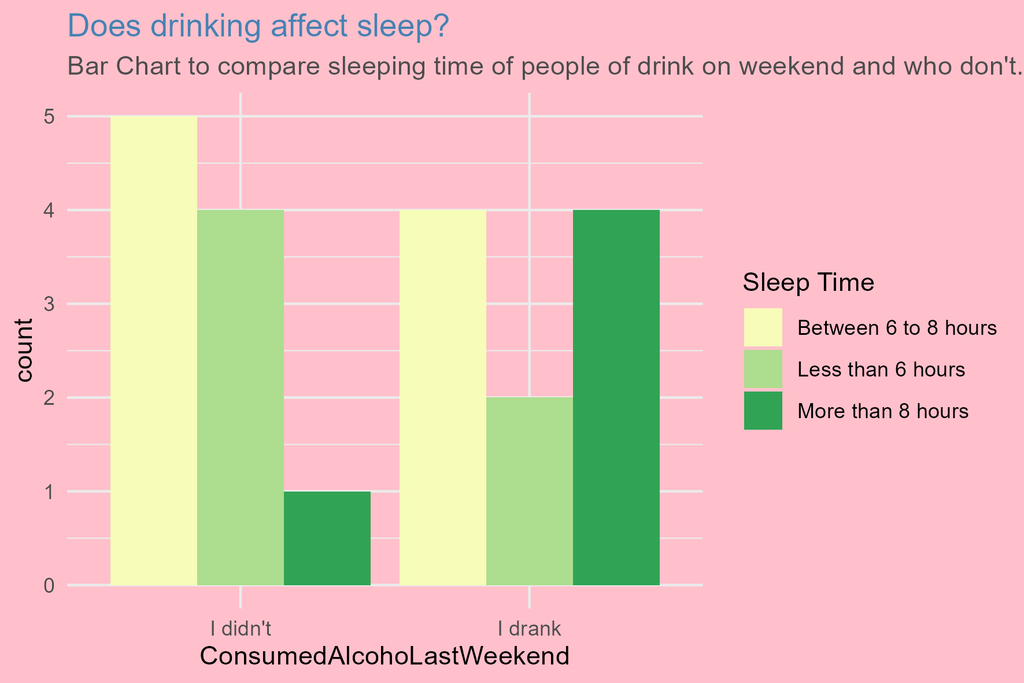

Bar chart comparing the sleep span of students according to whether they consumed alchol or not.

## Relatonship between Number of classes and Study time each day?

- The given plot fits a linear model for average study time each day for an individual and number of classes they had that day and if their is a positive or negative or no linear relationship between the two numerical variables.
- The visualization in my sample data plot revels their is a linear positive trend with some correlation while their might be some outliers(non-obvious) points,which could have been better revealed using a smooth curve and checking if they lie outside 95% confidence interval using **geom_smooth()**. However, I just wanted to check whether a linear relationship exists or not.

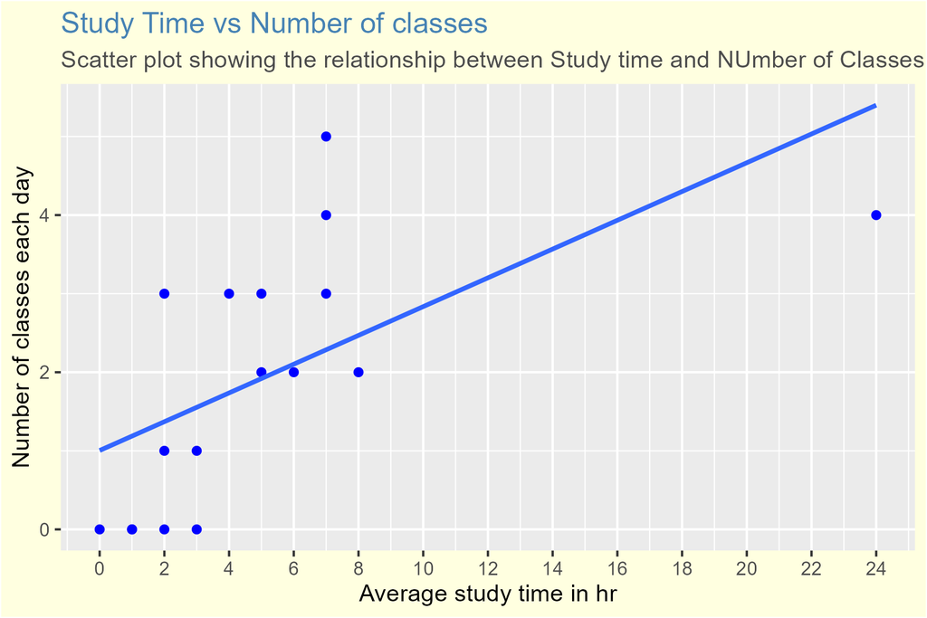

The given plot fits a linear model for average study time each day for an individual and number of classes they had that day and if their is a positive or negative or no linear relationship between the two numerical variables

## Relation between random guessed date and study time?

- The below box plot tries to reveal whether their is a hidden relationship between people guessing a random date has something to do with the average number of hours an individual studies.
- According to my sample data I collected the results shows that people who guessed the date after 2000s had more median study time compared to people who responded a random date after 2000s. However, the number of observation might be different for both the groups which might make the results different from what actually could be observed with large number of observations.

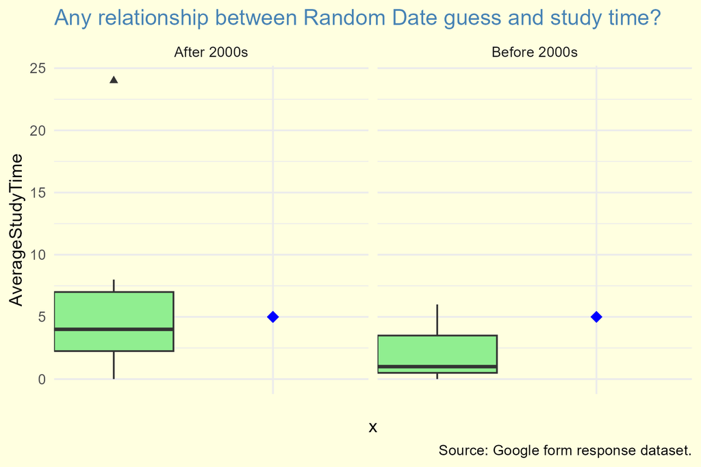

The below box plot tries to reveal whether their is a hidden relationship between people guessing a random date has something to do with the average number of hours an individual studies.

## Food Consumption vs Study Time

- The below box plot compares the number of people who consumed enough food, not enough food and too much food with the average number of hours they studies that particular day.
- The results from my sample data were quite obvious as more food would give more energy and a person would tend to study for quiet longer time and students who consumed more than 4 meals did spent more time studying compared to people who had less than 3 meals while the third category was consistent with being in between the others.
- The square **blue** dot in all the three whisker plot shows the mean value of number of hours studies in each category and which is pretty close to the median value(50% percentile) for all of them which also might give a idea that for larger number of observation the data might be normally distributed.

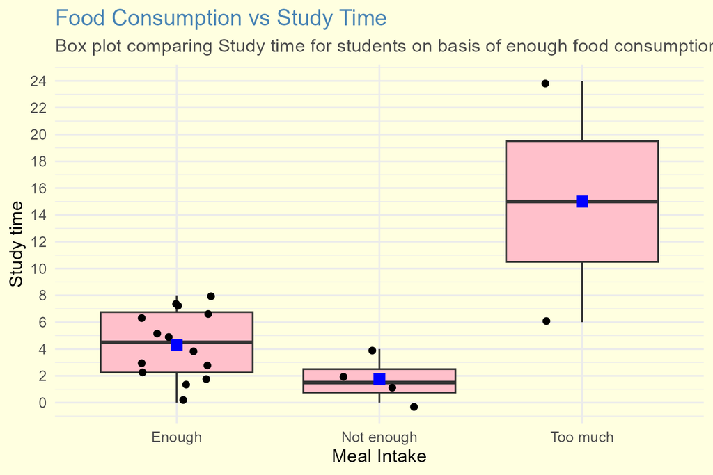

The below box plot compares the number of people who consumed enough food, not enough food and too much food with the average number of hours they studies that particular day.